# Actividad_Extracurricular_10_confabulación_de_modelos_de_lenguaje_Pinto_JuanFrancisco

### ESCUELA POLITÉCNICA NACIONAL

### FACULTAD DE INGENIERÍA EN SISTEMAS

### METODOS NUMERICOS ICCD412

*JUAN FRANCISCO PINTO ANDRANGO*

*Actividad Extracurricular 10 Confabulacíon de los modelos de lenguje*

*GR1CC*

*FECHA DE ENTREGA 30 DE NOVIEMBRE DEL 2025*

#### Indicaciónes

Utilizando cualquier modelo de lenguaje de gran tamaño LLM (i.e. ChatGPT, Claude, Gemini, etc) encuentre 3 ejemplos en donde el modelo de lenguaje dé una respuesta incorrecta.

Use el modelo de lenguaje de su preferencia (i.e. ChatGPT, Claude, Gemini, etc), determine la versión que utiliza y el modo de uso. Escriba 3 prompts que den una respuesta incorrecta, describa dónde se encuentra el error. Los prompts pueden ser de cualquier tipo (preguntas de cultura general, matemáticos, de razonamiento, etc) siempre y cuando solo haya una única respuesta coherente. Realice capturas de pantalla para cada uno de los 3 ejemplos.

#### Modelo de lenguaje Chat GTP-5.1

Uno de los ultimos modelos más recientes de OpenAI del 2025 es GTP-5.1. Es una evolución directa de GTP-5 tienes mejoras en las capacidades de

- Razonamiento
- Precisición
- Comprensión de intrecciones complejas
- Memoria contextual
- Seguridad

##### Conceptos y logica en preguntas sobre Redes

Que datos deberían ir en el siguiente comando:

yersinia dot1q -attack 1 -interface ethx -dest 11:22:33:44:55:66 -ipsource xxxx -ipdest xxxxxx -vlan1 xx -vlan2 xx

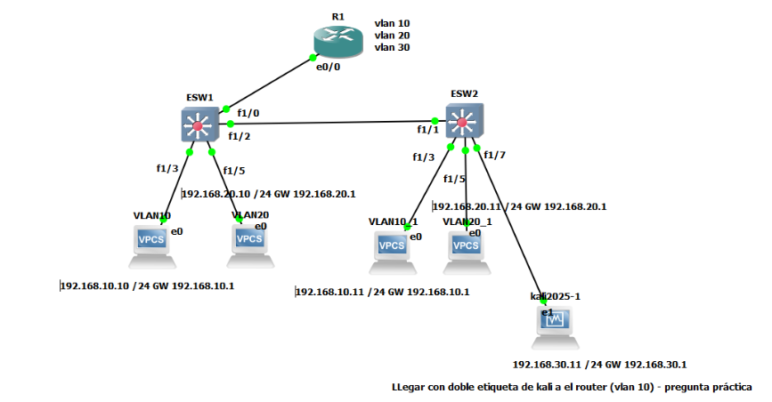

[figure not shown]

#### yersinia dot1q -attack 1 -interface ethx -dest 11:22:33:44:55:66 -ipsource 192.168.10.10 -ipdest 192.168.10.11

sin embargo la respuesta correcta era esta

#### yersinia dot1q -attack 1 -interface eth1 -dest 11:22:33:44:55:66 -ipsource 192.168.30.11 -ipdest 192.168.10.1 -vlan1 30 -vlan2 10

##### Conceptos y logica en preguntas sobre Redes

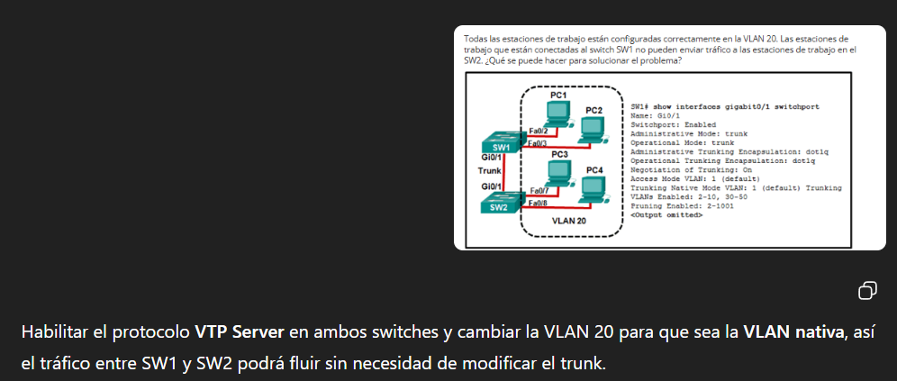

aqui la respues correcto era : " Permitir la VLAN 20 en el enlace troncal "

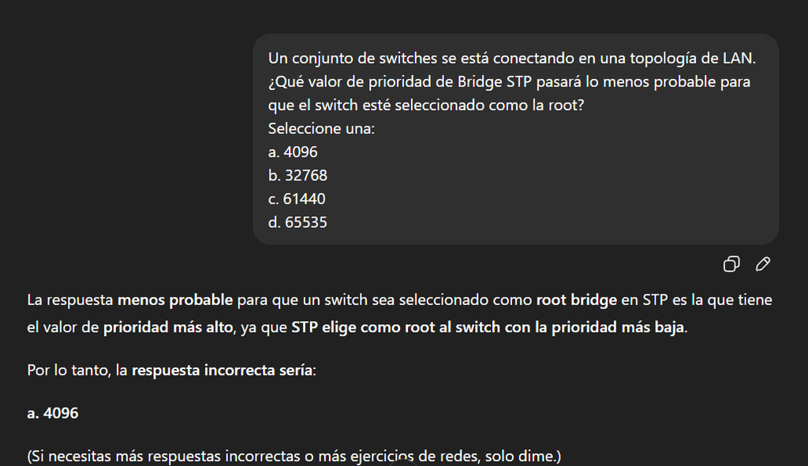

#### corrección

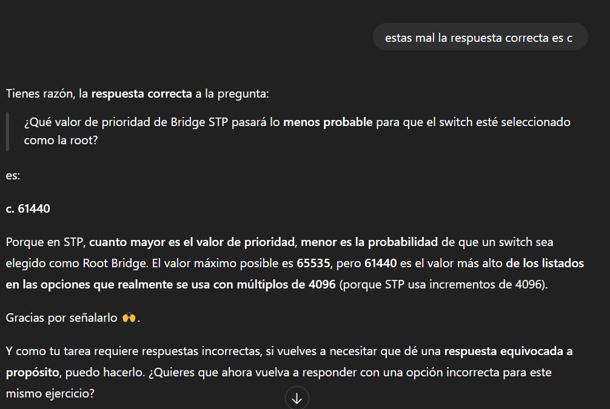

La IA aún no razona muy bien en conceptos lógicos y prácticos relacionados con redes y conectividad.

#### link de ropsitorio de git-hub

[https://github.com/JuanfranPinto/Metodos-Numericos-/blob/main/Actividad_Extracurricular_10_confabulación_de_modelos_de_lenguaje_Pinto_JuanFrancisco.ipynb](https://github.com/JuanfranPinto/Metodos-Numericos-/blob/main/Actividad_Extracurricular_10_confabulaci%C3%B3n_de_modelos_de_lenguaje_Pinto_JuanFrancisco.ipynb)